# What’s your CRAN number?

Extending the Erdos-Bacon-Sabbath concept

Matt Dray

24 April 2018

# 1 Purpose

- [Erdos number](https://en.wikipedia.org/wiki/Erdős_number)
- [Bacon number](https://en.wikipedia.org/wiki/Six_Degrees_of_Kevin_Bacon#Bacon_numbers)
- [Erdos-Bacon number](https://en.wikipedia.org/wiki/Erdős–Bacon_number)

I’ve used the code written by Francois Keck in his excellent blogpost ‘[Exploring the CRAN social network](http://www.pieceofk.fr/?p=431)’. His goal was to:

> reconstruct a social graph where each node would be a person… and two persons would be connected by an edge if they have collaborated on the same package

# 2 Prepare workspace

```r
library(purrr)
library(stringr)
library(tidyr)
library(dplyr)
library(tictoc)
library(beepr)
```

# 3 Get package authors

At first thought I would have to mine the CRAN website to get all the authors. Then I found out about the `CRAN_package_db()` function, which returns over 60 variables for each package on CRAN (name, version, depends, author, etc).

```r
cran_packages <- tools::CRAN_package_db()
```

At time of writing, this results 12544 separate packages.

# 4 Cleaning and preparing

For now we’re interested in the authors.

```r
cran_authors <- cran_packages$Author
```

The code in this chunk is directly from [Francois](http://www.pieceofk.fr/?p=431). It gets me exactly what I need: a list where each element is a package and contains a vector of authors. Mostly the code replaces inconsequential strings with a bunch of regex and the `stringr` functions. For example, some names in the author field are followed by something like `[aut, cre]`, meaning the person was the package `aut`hor and `cre`ator. Sometimes the names aren’t separated easily into a vector because of they contain phrases such as `and` and `with`, which we should also remove.

```r
cran_authors_clean <- cran_authors %>%
  # regex to replace unwanted text
  stringr::str_replace_all("\\(([^)]+)\\)", "") %>%
  stringr::str_replace_all("\\[([^]]+)\\]", "") %>%
  stringr::str_replace_all("<([^>]+)>", "") %>%
  stringr::str_replace_all("\n", " ") %>%
  stringr::str_replace_all("[Cc]ontribution.* from|[Cc]ontribution.* by|[Cc]ontributors", " ") %>%
  stringr::str_replace_all("\\(|\\)|\\[|\\]", " ") %>%
  # conversion
  iconv(to = "ASCII//TRANSLIT") %>%
  # further string substitution
  stringr::str_replace_all("'$|^'", "") %>%
  gsub("([A-Z])([A-Z]{1,})", "\\1\\L\\2", ., perl = TRUE) %>%
  gsub("\\b([A-Z]{1}) \\b", "\\1\\. ", .) %>%
  # further string substittion with map()
  purrr::map(stringr::str_split, ",|;|&| \\. |--|(?<=[a-z])\\.| [Aa]nd | [Ww]ith | [Bb]y ", simplify = TRUE) %>%
  purrr::map(stringr::str_replace_all, "[[:space:]]+", " ") %>%
  purrr::map(stringr::str_replace_all, " $|^ | \\.", "") %>%
  purrr::map(function(x) x[stringr::str_length(x) != 0]) %>%
  # reintroduce package names
  purrr::set_names(cran_packages$Package) %>%
  magrittr::extract(map_lgl(., function(x) length(x) > 1))
```

# 5 To dataframe

Turn the list into a two-column tidy dataframe with a row for each package-author relationship.

```r
cran_authors_df <- cran_authors_clean %>%
  tibble::enframe() %>%
  tidyr::unnest() %>%
  dplyr::transmute(name = name, author = tolower(value))
```

We can have a quick look at the top authors by count.

```r
cran_authors_df %>%
  janitor::tabyl(author) %>%
  dplyr::arrange(desc(n)) %>%
  slice(1:20) %>%
  knitr::kable()
```

| author | n | percent |
| --- | --- | --- |
| rstudio | 109 | 0.0044158 |
| hadley wickham | 105 | 0.0042538 |
| kurt hornik | 62 | 0.0025117 |
| martin maechler | 52 | 0.0021066 |
| achim zeileis | 49 | 0.0019851 |
| inc | 48 | 0.0019446 |
| scott chamberlain | 48 | 0.0019446 |
| dirk eddelbuettel | 47 | 0.0019041 |
| r. core team | 47 | 0.0019041 |
| jeroen ooms | 38 | 0.0015395 |
| person | 37 | 0.0014989 |
| brian ripley | 35 | 0.0014179 |
| yihui xie | 35 | 0.0014179 |
| bob rudis | 32 | 0.0012964 |
| jj allaire | 31 | 0.0012559 |
| kirill m“uller | 28 | 0.0011343 |
| romain francois | 28 | 0.0011343 |
| torsten hothorn | 28 | 0.0011343 |
| ben bolker | 27 | 0.0010938 |
| douglas bates | 26 | 0.0010533 |

# 6 Graph

```r
library(tidygraph)

cran_graph <- tidygraph::as_tbl_graph(cran_authors_df)

cran_graph %>%
  activate(nodes) %>%
  mutate(id = row_number())
```

```
## # A tbl_graph: 22340 nodes and 24684 edges
## #
## # A directed multigraph with 1987 components
## #
## # Node Data: 22,340 x 2 (active)
##   name           id
##   <chr>       <int>
## 1 abc             1
## 2 ABCanalysis     2
## 3 abc.data        3
## 4 abcdeFBA        4
## 5 ABCoptim        5
## 6 ABCp2           6
## # ... with 2.233e+04 more rows
## #
## # Edge Data: 24,684 x 2
##    from    to
##   <int> <int>
## 1     1  6918
## 2     1  6919
## 3     1  6920
## # ... with 2.468e+04 more rows
```

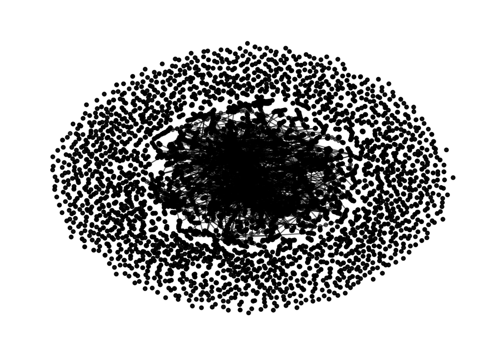

```r
library(ggraph)

ggraph::ggraph(cran_graph, layout = "nicely") +
  geom_edge_link0(alpha = 0.6) +
  #geom_node_point()
  geom_node_point(alpha = 0.6) +
  theme_graph()
```

Check out [Francois’s blogpost](http://www.pieceofk.fr/?p=431) to see some visualisations and network statistics of these data.